# Homework3_Kai Wang

## 1 Separability

For points in the convex hull of $\{X_n\}$, we can calculate its linear discriminants as $y(x) = w^T X + w_0$.

Sine $X=\sum_n \alpha_n X_n$, we have $y(x) = w^T (\sum_n \alpha_n X) + w_0$.

And since $\sum_n \alpha_n = 1$, we have $y(x) = \alpha_n(\sum_n w^T X+ w_0)>0$.

Similarly, the points in the convex hull $\{X_m'\}$, we have $y(x') = \alpha_n'(\sum_n w^T X'+ w_0)<0$.

The intersection of these two convex hulls are $y(xx')=\alpha_n(\sum_n w^T X+ w_0)= \alpha_n'(\sum_n w^T X'+ w_0)$, however, $y(xx')$ cannot be greater than 0 and less than 0 at the same time, so $y(xx')$ does not exist. So when two sets of points are linearly seperable, their convex hulls do not intersect.

## 2 Logistic regression and gradient descent

### a

$\sigma ' (a)= \frac{e^{-a}}{(1+e^{-a})^2}$.

$\begin{aligned} \sigma(a)(1-\sigma(a))&=\frac{1}{1+e^{-a}}\frac{e^{-a}}{1+e^{-a}}\\ &=\frac{e^{-a}}{(1+e^{-a})^2}\\ &=\sigma ' (a) \end{aligned}$

### b

$\begin{aligned} L_w (\{(x^{(i)},y^{(i)})\}_{i=1}^n) &= \sum_{i=1}^n \{-y^{(i)} \log[h_w (x^{(i)})] -(1-y^{(i)})\log[1-h_w(x^{(i)})]\}\\ &= \sum_{i=1}^n \{-y^{(i)} \log [\frac{1}{1+e^{-w^T x^{(i)}}}]-(1-y^{(i)})\log[1-\frac{1}{1+e^{-w^T x^{(i)}}}]\} \end{aligned}$

$\begin{aligned} \frac{\partial L_w (\{(x^{(i)},y^{(i)})\}_{i=1}^n)}{\partial w_j} &= \frac{\partial \sum_{i=1}^n \{-y^{(i)} \log [\frac{1}{1+e^{-w^T x^{(i)}}}]-(1-y^{(i)})\log[1-\frac{1}{1+e^{-w^T x^{(i)}}}]\}}{\partial w_j} \\ &= \sum_{i=1}^n -y^{(i)}({1+e^{-w^T x^{(i)}}}) \frac{e^{-w^T x^{(i)}}x^{(i)}}{(1+e^{-w^T x^{(i)}})^2}-(1-y^{(i)})\frac{{1+e^{-w^T x^{(i)}}}}{{e^{-w^T x^{(i)}}}}\frac{e^{-w^T x^{(i)}}x^{(i)}e^{-w^T x^{(i)}}-x^{(i)}e^{-w^T x^{(i)}}(1+e^{-w^T x^{(i)}})}{(1+e^{-w^T x^{(i)}})^2}\\ &= \sum_{i=1}^n -y^{(i)}\frac{e^{-w^T x^{(i)}}x^{(i)}}{1+e^{-w^T x^{(i)}}}-(1-y^{(i)})\frac{x^{(i)}e^{-w^T x^{(i)}}-x^{(i)}(1+e^{-w^T x^{(i)}})}{1+e^{-w^T x^{(i)}}}\\ &= \sum_{i=1}^n -y^{(i)}\frac{e^{-w^T x^{(i)}}x^{(i)}}{1+e^{-w^T x^{(i)}}}+(1-y^{(i)})\frac{x^{(i)}}{1+e^{-w^T x^{(i)}}}\\ &= \sum_{i=1}^n -y^{(i)}\frac{e^{-w^T x^{(i)}}x^{(i)}}{1+e^{-w^T x^{(i)}}}+(1-y^{(i)})\frac{x^{(i)}}{1+e^{-w^T x^{(i)}}}\\ &= \sum_{i=1}^n \frac{(1-y^{(i)}-y^{(i)}e^{-w^T x^{(i)}})x^{(i)}}{1+e^{-w^T x^{(i)}}} \end{aligned}$

### c

A function f(x) is said to be convex if the following inequality holds true: $f\left( \alpha x + \left( 1 - \alpha\right) y \right) \leq \alpha f\left( x \right) + \left( 1 - \alpha\right) f\left( y \right)$.

So we can prove that $-\log[h_w (x)]$ and $-\log[1-h_w(x)]$ are convex instead.

$\begin{aligned} \nabla_w -\log[h_w (x)] &= \nabla_w[\log(1+e^{-w^T x}]\\ &= \frac{-e^{-w^T x}}{1+e^{-w^T x}}x\\ &= (\frac{1}{1+e^{-w^T x}}-1)x\\ &= (h_w(x)-1)x \end{aligned}$

$\begin{aligned} \nabla_w^2 -\log[h_w (x^{(i)})] &= \nabla_w^2[\log(1+e^{-w^T x})]\\ &= \nabla_w(h_w(x)-1)x\\ &=h_w(x)(1-h_w(x))xx^T \end{aligned}$

$\forall z: z^T \nabla_w^2 -\log[h_w (x)] = z^T[h_w(x)(1-h_w(x))xx^T]z = h_w(x)(1-h_w(x))(x^T z)^2 \geq 0$, so the hessian matrix is positive semi-definite, so we proved that $-\log[h_w (x^{(i)})]$ is a convex function.

Similarly,

$\begin{aligned} \nabla_w^2 -\log[1-h_w(x)] &= \nabla_w(\nabla_w(-\log(1-\frac{1}{e^{-w^T x}}))\\ &= \nabla_w(x+\nabla_w [\log(1+e^{-w^T x})])\\ &= \nabla_w^2[-\log(h_w (x))] \end{aligned}$

We already showed that this hassian matrix is positive semi-definie, so $-\log[1-h_w(x)]$ is also convex. Hence the cross-entropy loss is also convex.

### d

```python
import pandas as pd
import numpy as np

products = pd.read_csv('amazon_baby_small.csv')
products['high_rating'] = (products['rating'] > 4)
```

```python
import json
with open('important_words.json', 'r') as f: # Reads the list of most frequent words
    important_words = json.load(f)
important_words = [str(s) for s in important_words]
```

```python
products = products.fillna({'review':''})  # fill in N/A's in the review column

def remove_punctuation(text):
    import string
    return text.replace(string.punctuation, ' ')

products['review_clean'] = products['review'].apply(remove_punctuation)
```

```python
for word in important_words:
    products[word] = products['review_clean'].apply(lambda s : s.split().count(word))
```

```python
products['contains_perfect'] = products['perfect'].apply(lambda x: 1 if x>=1 else 0)
count = np.sum(list(products['contains_perfect']))
print(count)
```

```
2808
```

```python
products = products.drop(['name', 'review', 'review_clean', 'rating'], axis = 1)
```

```python
def get_numpy_data(dataframe, features, label):
    dataframe['intercept'] = 1
    features = ['intercept'] + features
    feature_matrix = np.array(dataframe[features])
    label_array = np.array(dataframe[label])
    return(feature_matrix, label_array)
```

```python
feature_matrix, high_rating = get_numpy_data(products, important_words, 'high_rating')
```

```python
'''
produces probablistic estimate for P(y_i = +1 | x^(i), w).
estimate ranges between 0 and 1.
'''
def predict_probability(feature_matrix, coefficients):
    # Take dot product of feature_matrix and coefficients
    # YOUR CODE HERE
    scores = np.dot(feature_matrix, coefficients)

    # Compute the conditional probability
    # YOUR CODE HERE
    predictions = 1. / (1. + np.exp(-scores))

    # return predictions
    return predictions
```

```python
dummy_feature_matrix = np.array([[1.,2.,3.], [1.,-1.,-1]])
dummy_coefficients = np.array([1., 3., -1.])

correct_scores      = np.array( [ 1.*1. + 2.*3. + 3.*(-1.),          1.*1. + (-1.)*3. + (-1.)*(-1.) ] )
correct_predictions = np.array( [ 1./(1+np.exp(-correct_scores[0])), 1./(1+np.exp(-correct_scores[1])) ] )

print ('The following outputs must match ')
print ('------------------------------------------------')
print ('correct_predictions           =', correct_predictions)
print ('output of predict_probability =', predict_probability(dummy_feature_matrix, dummy_coefficients))
```

```
The following outputs must match
------------------------------------------------
correct_predictions           = [0.98201379 0.26894142]
output of predict_probability = [0.98201379 0.26894142]
```

```python
def feature_derivative(errors, feature):
    # Compute the dot product of errors and feature
    derivative = np.dot(errors, feature)

    # Return the derivative
    return derivative
```

```python
def compute_log_likelihood(feature_matrix, high_rating, coefficients):

    scores = np.dot(feature_matrix, coefficients)
    sig = 1./(1. + np.exp(-scores))

    ## YOUR CODE HERE, do check overflow/underflow problem.
    lp = np.sum(high_rating*np.log(sig) + (1-high_rating)*np.log(1-sig))

    return lp
```

```python
# here uses another way to compute log-likelihood. Don't worry about it too much.

dummy_feature_matrix = np.array([[1.,2.,3.], [1.,0.,0]])
dummy_coefficients = np.array([1., 3., -1])
dummy_high_rating = np.array([0, 1])

correct_indicators  = np.array( [ 0==+1,                                       1==+1 ] )
correct_scores      = np.array( [ 1.*1. + 2.*3. + 3.*(-1.),                     1.*1. + (0.)*3. + (0.)*(-1.) ] )
correct_first_term  = np.array( [ (correct_indicators[0]-1)*correct_scores[0],  (correct_indicators[1]-1)*correct_scores[1] ] )
correct_second_term = np.array( [ np.log(1. + np.exp(-correct_scores[0])),      np.log(1. + np.exp(-correct_scores[1])) ] )

correct_ll          =      sum( [ correct_first_term[0]-correct_second_term[0], correct_first_term[1]-correct_second_term[1] ] )

print ('The following outputs must match ')
print ('------------------------------------------------')
print ('correct_log_likelihood           =', correct_ll)
print ('output of compute_log_likelihood =', compute_log_likelihood(dummy_feature_matrix, dummy_high_rating, dummy_coefficients))
```

```
The following outputs must match
------------------------------------------------
correct_log_likelihood           = -4.331411615436032
output of compute_log_likelihood = -4.331411615436033
```

```python
from math import sqrt

def logistic_regression(feature_matrix, high_rating, initial_coefficients, step_size, max_iter):
    coefficients = np.array(initial_coefficients) # make sure it's a numpy array
    for itr in range(max_iter):

        # Predict P(y^(i) = +1|x^(i),w) using your predict_probability() function
        # YOUR CODE HERE
        predictions = predict_probability(feature_matrix, coefficients)

        # Compute the errors as y - predictions
        errors = high_rating - predictions
        for j in range(len(coefficients)): # loop over each coefficient

            # Recall that feature_matrix[:,j] is the feature column associated with coefficients[j].
            # Compute the derivative for coefficients[j]. Save it in a variable called derivative
            # YOUR CODE HERE
            derivative = feature_derivative(errors, feature_matrix[:,j])

            # add the step size times the derivative to the current coefficient
            ## YOUR CODE HERE
            coefficients[j] = coefficients[j] + derivative*step_size

        # Checking whether log likelihood is increasing
        if itr <= 15 or (itr <= 100 and itr % 10 == 0) or (itr <= 1000 and itr % 100 == 0) \
        or (itr <= 10000 and itr % 1000 == 0) or itr % 10000 == 0:
            lp = compute_log_likelihood(feature_matrix, high_rating, coefficients)
            print ('iteration %*d: log likelihood of observed labels = %.8f' % \
                (int(np.ceil(np.log10(max_iter))), itr, lp))
    return coefficients
```

```python
coefficients = logistic_regression(feature_matrix, high_rating, initial_coefficients=np.zeros(194),
                                   step_size=1e-7, max_iter=301)
```

```
iteration   0: log likelihood of observed labels = -34770.14654431
iteration   1: log likelihood of observed labels = -34767.87459771
iteration   2: log likelihood of observed labels = -34765.60560727
iteration   3: log likelihood of observed labels = -34763.33956017
iteration   4: log likelihood of observed labels = -34761.07644369
iteration   5: log likelihood of observed labels = -34758.81624520
iteration   6: log likelihood of observed labels = -34756.55895218
iteration   7: log likelihood of observed labels = -34754.30455219
iteration   8: log likelihood of observed labels = -34752.05303288
iteration   9: log likelihood of observed labels = -34749.80438201
iteration  10: log likelihood of observed labels = -34747.55858740
iteration  11: log likelihood of observed labels = -34745.31563700
iteration  12: log likelihood of observed labels = -34743.07551881
iteration  13: log likelihood of observed labels = -34740.83822096
iteration  14: log likelihood of observed labels = -34738.60373163
iteration  15: log likelihood of observed labels = -34736.37203911
iteration  20: log likelihood of observed labels = -34725.25512468
iteration  30: log likelihood of observed labels = -34703.22456228
iteration  40: log likelihood of observed labels = -34681.45613564
iteration  50: log likelihood of observed labels = -34659.93984484
iteration  60: log likelihood of observed labels = -34638.66639484
iteration  70: log likelihood of observed labels = -34617.62714006
iteration  80: log likelihood of observed labels = -34596.81403315
iteration  90: log likelihood of observed labels = -34576.21957777
iteration 100: log likelihood of observed labels = -34555.83678487
iteration 200: log likelihood of observed labels = -34362.40365516
iteration 300: log likelihood of observed labels = -34185.00552786
```

```python
# Compute the scores as a dot product between feature_matrix and coefficients.
scores = np.dot(feature_matrix, coefficients)
```

```python
class_pred = scores>0
print (list(class_pred).count(True))
```

```
26998
```

### Question i: How many reviews were predicted to have high rating?

There are 26998 reviews that were predicted to have high ratings.

```python
from __future__ import division
num_mistakes = list(high_rating == class_pred).count(False)
accuracy = (len(products) - num_mistakes)/len(products)
print ("-----------------------------------------------------")
print ('# Reviews   correctly classified =', len(products) - num_mistakes)
print ('# Reviews incorrectly classified =', num_mistakes)
print ('# Reviews total                  =', len(products))
print ("-----------------------------------------------------")
print ('Accuracy = %.2f' % accuracy)
```

```
-----------------------------------------------------
# Reviews   correctly classified = 33089
# Reviews incorrectly classified = 17077
# Reviews total                  = 50166
-----------------------------------------------------
Accuracy = 0.66
```

### Question ii: What is the accuracy of the model on predictions made above? (round to 2 digits of accuracy)

The prediction accuracy is 0.66.

```python
coefficients = list(coefficients[1:]) # exclude intercept
word_coefficient_tuples = [(word, coefficient) for word, coefficient in zip(important_words, coefficients)]
word_coefficient_tuples = sorted(word_coefficient_tuples, key=lambda x:x[1], reverse=True)
```

```python
word_coefficient_tuples
```

```
[('love', 0.05417175110031363),
 ('loves', 0.03341634129158078),
 ('easy', 0.03338913748001677),
 ('great', 0.025580515307137473),
 ('perfect', 0.018573255618985464),
 ('recommend', 0.018198089912211276),
 ('baby', 0.015214316424304965),
 ('best', 0.012004878798543237),
 ('daughter', 0.009724230930764759),
 ('old', 0.009607388050573889),
 ('fits', 0.00917736061196277),
 ('also', 0.009096143871771314),
 ('soft', 0.008943944922918836),
 ('happy', 0.00719076203015758),
 ('every', 0.006683151200866263),
 ('well', 0.00624658635328378),
 ('without', 0.0059343223690781904),
 ('comfortable', 0.005554796613533447),
 ('son', 0.004873375405488079),
 ('play', 0.004711611981100412),
 ('room', 0.004500995877516566),
 ('diaper', 0.004107433778957112),
 ('worth', 0.003944765282505371),
 ('many', 0.003736816435735063),
 ('months', 0.0037237525514986036),
 ('car', 0.0037204549714334573),
 ('kids', 0.0032778115843018056),
 ('clean', 0.0032011958051949255),
 ('little', 0.003179969958054386),
 ('night', 0.003082072689961903),
 ('year', 0.0030409244938375043),
 ('us', 0.0024001272043584795),
 ('easily', 0.002275536838470771),
 ('crib', 0.0021403384334870296),
 ('set', 0.0017015566795742273),
 ('size', 0.0015372045927096367),
 ('looking', 0.0014303982763842645),
 ('purchased', 0.0011362063610430516),
 ('day', 0.0010736403038844762),
 ('bottles', 0.0010670141788825323),
```

[output cut: 138 more lines]

```
 ('think', -0.011607416182415974),
 ('better', -0.01171893785837706),
 ('way', -0.01200636517389574),
 ('monitor', -0.01212466087136327),
 ('thought', -0.012664530663116253),
 ('good', -0.01460154255474313),
 ('really', -0.014670316455461472),
 ('hard', -0.015237868674725085),
 ('back', -0.016009093804293415),
 ('work', -0.016221373513787968),
 ('product', -0.017354095077474443),
 ('could', -0.018893796476944138),
 ('get', -0.023544894371514233),
 ('like', -0.031072720033253332),
 ('would', -0.045868342428508284)]
```

### Question iii: What are the top 3 most positively weighted words (according to our model)?

According to our model, the three most positively weighted words are "love", "loves", "easy".

## 3 Boosting

### a

If the weak learning assumption holds, we have $\epsilon_t = \frac{1}{2}-\gamma_t$, and $\gamma_t>\gamma_{WLA}$, for all t.

$\begin{aligned} R^\text{train}(\lambda_{t+1}) &= R^\text{train}(\lambda_t + \alpha_t e_{j_t})\\ &= \frac{1}{n}\sum_{i=1}^n e^{-[M(\lambda_t + \alpha_t e_{j_t})]_i}\\ &= e^{-\alpha_t} \frac{1}{n}\sum_{i:M_{ij_t =1}}e^{-(M\lambda_t)_i}+e^{\alpha_t} \frac{1}{n}\sum_{i:M_{ij_t =-1}}e^{-(M\lambda_t)_i} \end{aligned}$

We have $d_{t,i} = e^{-(M\lambda_t)_i}/Z_t$ where $Z_t = \sum_{i=1}^n e^{-(M\lambda_t)_i}$. So $R^\text{train}(\lambda_{t+1}) = R^\text{train}(\lambda_{t})[e^{-\alpha} d_+ + e^{\alpha} d_-]$

We have $\alpha_t = \frac{1}{2}\ln (\frac{1-d_-}{d_-}) = \frac{1}{2}\ln (\frac{1-\epsilon_t}{\epsilon_t})$.

$\begin{aligned} R^\text{train}(\lambda_{t+1}) &= R^\text{train}(\lambda_{t})[e^{-\alpha}(1-d_-) + e^{\alpha} d_-]\\ &= \frac{d_-}{1-d_-}(1-d_-)+(\frac{d_-}{1-d_-})^{\frac{1}{2}}\\ &= R^\text{train}2[\epsilon_t(1-\epsilon_t)]^\frac{1}{2} \end{aligned}$

Start with $\lambda_1 = 0$, we have $R^\text{train}(\lambda_{T}) = \prod_{i=1}^T 2\sqrt{\epsilon_t(1-\epsilon_t)} = \prod_{i=1}^T 2\sqrt{(\frac{1}{2}-\gamma_t)(\frac{1}{2}+\gamma_t)} = \prod_{i=1}^T\sqrt{1-4\gamma_t^2}$.

From the inequality $1+x\leq e^x$,we have $R^\text{train}(\lambda_{T}) \leq \prod_{i=1}^T \sqrt{e^{-4\gamma_t^2}}= \prod_{i=1}^Te^{-2\gamma_t^2}= e^{-2\sum_{i=1}^T \gamma_t^2}\leq e^{-2T \gamma_{WLA}^2}$.

The upper bound approaches $0$ when $T$ grows.

Therefore, if the weak learning assumption holds, the boosting model eventually classifies the training set perfectly.

### b

The exponential loss is $R^\text{train}(\lambda) = \sum_{i=1}^n w_i e^{-(M\lambda)_i}$.

We can do coordinate descent on the exponential loss. At each iteration, we will choose a coordinate for $lambda$, called $j_t$, and move $\alpha_t$ in the $j_t^{th}$ direction. By doing so, each weak classifier corresponds to a direction in the space and $\alpha_t$ corresponds to a distance in that direction. We need to find the direction $j$ which has the steepest directional derivative. Let $e_j$ be a vector with 1 in the $j^{th}$ entry and 0 elsewhere.

$\begin{aligned} j_t &\in \text{argmax}_j [-\frac{\partial R^\text{train}(\lambda_{t}+\alpha e_j)}{\partial \alpha}|_{\alpha=0}]\\ &= \text{argmax}_j [-\frac{\partial}{\partial\alpha}[\sum_{i=1}^n w_i e^{-(M((\lambda_{t}+\alpha e_j))_i}]|_{\alpha=0}]\\ &= \text{argmax}_j [-\frac{\partial}{\partial\alpha}[\sum_{i=1}^n w_i e^{-(M\lambda_{t})_i-\alpha(M e_j)_i}]|_{\alpha=0}]\\ &= \text{argmax}_j [-\frac{\partial}{\partial\alpha}[\sum_{i=1}^n w_i e^{-(M\lambda_{t})_i-\alpha(M e_j)_i}]|_{\alpha=0}]\\ &= \text{argmax}_j [-\frac{\partial}{\partial\alpha}[\sum_{i=1}^n w_i e^{-(M\lambda_{t})_i-\alpha M_{ij}}]|_{\alpha=0}]\\ &= \text{argmax}_j [\sum_{i=1}^n w_i M_{ij} e^{-(M\lambda_{t})_i}] \end{aligned}$

We initialize the weight vector $d_{t,i} = w_i$ for all $i$.

We have $\begin{equation} d_{t+1,i} = \frac{d_{t,i}}{Z_t} \begin{cases} e^{-\alpha_t} &\text{if} y_i = h_{(t)}(x_i)\\ e^{\alpha_t} &\text{if} y_i \neq h_{(t)}(x_i) \end{cases} \end{equation}$, where $Z_t = \sum_{i=1}^n e^{-(M\lambda_t)_i}$.

Hence, we have $j_t \in \text{argmax}_j \sum_{i=1}^n w_i M_{ij}d_{t,i} = \text{argmax}_j(d^T_t M)_j$.

Then we can find $\alpha_t$ by setting the derivate to 0.

$\begin{aligned} 0 &= \frac{\partial R^\text{train}(\lambda_{t}+\alpha e_j)}{\partial \alpha} |_{\alpha_t}\\ &= \sum_{i=1}^n w_i M_{ij} e^{-(M\lambda_{t})_i - \alpha_t M_{ij_t}}\\ &= \sum_{i:M_{ij_t}=1}w_i e^{-(M\lambda_{t})_i - \alpha_t} - \sum_{i:M_{ij_t}=-1}w_ie^{-(M\lambda_{t})_i + \alpha_t}\\ &= \sum_{i:M_{ij_t}=1}w_i d_{t,i} e^{-\alpha_t} - \sum_{i:M_{ij_t}=-1}w_i d_{t,i} e^{\alpha_t}\\ &= d_+ e^{-\alpha_t} - d_- e^{\alpha_t} \end{aligned}$

Hence, $\alpha_t = \frac{1}{2}\ln\frac{d_+}{d_-}$.

So the weighted version of AdaBoost is:

$d_{t,i} = w_i$ for all $i$

$\lambda_1 = 0$

loop from $t = 1$ to $T$

$j_t \in \text{argmax}_j(d^T_t M)_j$

$d_- = \sum_{i:M_{ij_t}=-1}w_i d_{t,i}$

$\alpha_t = \frac{1}{2}\ln\frac{1-d_-}{d_-}$

$\lambda_{t+1} = \lambda_t + \alpha_t e_{j_t}$

$d_{t+1,i} = \frac{e^{-(M+\lambda_{t=1})_i}}{Z_{t+1}}$

end.

### c

```python
import pandas as pd
import numpy as np
```

```python
import matplotlib.pyplot as plt
%matplotlib inline
```

```python
loans = pd.read_csv('loan_small.csv')
```

```python
features = ['grade',              # grade of the loan
            'term',               # the term of the loan
            'home_ownership',     # home ownership status: own, mortgage or rent
            'emp_length',         # number of years of employment
           ]

loans['safe_loans'] = loans['loan_status'].apply(lambda x : +1 if x=='Fully Paid' else -1)

## please update pandas to the newest version in order to execute the following line
loans.drop(['loan_status'], axis = 1, inplace=True)

target = 'safe_loans' # this variable will be used later
```

```python
loans = pd.get_dummies(loans)
features = list(loans.columns)
features.remove('safe_loans')  # Remove the response variable
features
```

```
['term_ 36 months',
 'term_ 60 months',
 'grade_A',
 'grade_B',
 'grade_C',
 'grade_D',
 'grade_E',
 'grade_F',
 'grade_G',
 'home_ownership_MORTGAGE',
 'home_ownership_NONE',
 'home_ownership_OTHER',
 'home_ownership_OWN',
 'home_ownership_RENT',
 'emp_length_1 year',
 'emp_length_10+ years',
 'emp_length_2 years',
 'emp_length_3 years',
 'emp_length_4 years',
 'emp_length_5 years',
 'emp_length_6 years',
 'emp_length_7 years',
 'emp_length_8 years',
 'emp_length_9 years',
 'emp_length_< 1 year']
```

```python
from sklearn.model_selection import train_test_split

train_data, test_data = train_test_split(loans, test_size = 0.2, random_state=1)
```

```python
def intermediate_node_weighted_mistakes(labels_in_node, data_weights):
    # Sum the weights of all entries with label +1
    total_weight_positive = np.sum(data_weights[labels_in_node == +1])

    # Sum the weights of all entries with label -1
    ### YOUR CODE HERE
    total_weight_negative = np.sum(data_weights[labels_in_node == -1])

    # Return the tuple (weight, class_label) representing the lower of the two weights
    #    class_label should be an integer of value +1 or -1.
    # If the two weights are identical, return (weighted_mistakes_all_positive,+1)
    ### YOUR CODE HERE
    if (total_weight_positive <= total_weight_negative):
        return(total_weight_positive, -1)
    else:
        return (total_weight_negative, +1)
```

```python
example_labels = pd.Series([-1, -1, 1, 1, 1])
example_data_weights = pd.Series([1., 2., .5, 1., 1.])
if intermediate_node_weighted_mistakes(example_labels, example_data_weights) == (2.5, -1):
    print ('Test passed!')
else:
    print ('Test failed... try again!')
```

```
Test passed!
```

```python
#If the data is identical in each feature, this function should return None

def best_splitting_feature(data, features, target, data_weights):

    # These variables will keep track of the best feature and the corresponding error
    best_feature = None
    best_error = float('+inf')
    num_points = float(len(data))

    # Loop through each feature to consider splitting on that feature
    for feature in features:

        # The left split will have all data points where the feature value is 0
        # The right split will have all data points where the feature value is 1
        left_split = data[data[feature] == 0]
        right_split = data[data[feature] == 1]

        # Apply the same filtering to data_weights to create left_data_weights, right_data_weights
        ## YOUR CODE HERE
        left_data_weights = data_weights[data[feature] == 0]
        right_data_weights = data_weights[data[feature] == 1]

        # Calculate the weight of mistakes for left and right sides
        ## YOUR CODE HERE
        left_weighted_mistakes, left_class = intermediate_node_weighted_mistakes(left_split[target], left_data_weights)
        right_weighted_mistakes, right_class = intermediate_node_weighted_mistakes(right_split[target], right_data_weights)

        # Compute weighted error by computing
        #  ( [weight of mistakes (left)] + [weight of mistakes (right)] ) / [total weight of all data points]
        ## YOUR CODE HERE
        error = (left_weighted_mistakes + right_weighted_mistakes) / (sum(left_data_weights) + sum(right_data_weights))

        # If this is the best error we have found so far, store the feature and the error
        if error < best_error:
            best_feature = feature
            best_error = error

    # Return the best feature we found
    return best_feature
```

```python
example_data_weights = np.array(len(train_data)* [1.5])
if best_splitting_feature(train_data, features, target, example_data_weights) == 'term_ 36 months':
    print ('Test passed!')
else:
    print ('Test failed... try again!')
```

```
Test passed!
```

```python
def create_leaf(target_values, data_weights):

    # Create a leaf node
    leaf = {'splitting_feature' : None,
            'is_leaf': True}

    # Computed weight of mistakes.
    weighted_error, best_class = intermediate_node_weighted_mistakes(target_values, data_weights)
    # Store the predicted class (1 or -1) in leaf['prediction']
    ## YOUR CODE HERE
    leaf['prediction'] = best_class

    return leaf
```

```python
def weighted_decision_tree_create(data, features, target, data_weights, current_depth = 1, max_depth = 10):
    remaining_features = features[:] # Make a copy of the features.
    target_values = data[target]
    print ("--------------------------------------------------------------------")
    print ("Subtree, depth = %s (%s data points)." % (current_depth, len(target_values)))

    # Stopping condition 1. Error is 0.
    if intermediate_node_weighted_mistakes(target_values, data_weights)[0] <= 1e-15:
        print ("Stopping condition 1 reached.")
        return create_leaf(target_values, data_weights)

    # Stopping condition 2. No more features.
    if remaining_features == []:
        print ("Stopping condition 2 reached." )
        return create_leaf(target_values, data_weights)

    # Additional stopping condition (limit tree depth)
    if current_depth > max_depth:
        print ("Reached maximum depth. Stopping for now.")
        return create_leaf(target_values, data_weights)

    # If all the datapoints are the same, splitting_feature will be None. Create a leaf
    splitting_feature = best_splitting_feature(data, features, target, data_weights)
    remaining_features.remove(splitting_feature)

    left_split = data[data[splitting_feature] == 0]
    right_split = data[data[splitting_feature] == 1]

    left_data_weights = data_weights[data[splitting_feature] == 0]
    right_data_weights = data_weights[data[splitting_feature] == 1]

    print ("Split on feature %s. (%s, %s)" % (\
              splitting_feature, len(left_split), len(right_split)))

    # Create a leaf node if the split is "perfect"
    if len(left_split) == len(data):
        print ("Creating leaf node.")
        return create_leaf(left_split[target], data_weights)
    if len(right_split) == len(data):
        print ("Creating leaf node.")
        return create_leaf(right_split[target], data_weights)

    # Repeat (recurse) on left and right subtrees
    left_tree = weighted_decision_tree_create(left_split, remaining_features, target, left_data_weights, current_depth + 1, max_depth)
    right_tree = weighted_decision_tree_create(right_split, remaining_features, target, right_data_weights, current_depth + 1, max_depth)

    return {'is_leaf'          : False,
            'prediction'       : None,
            'splitting_feature': splitting_feature,
            'left'             : left_tree,
            'right'            : right_tree}
```

```python
def count_nodes(tree):
    if tree['is_leaf']:
        return 1
    return 1 + count_nodes(tree['left']) + count_nodes(tree['right'])
```

```python
example_data_weights = np.array([1.0 for i in range(len(train_data))])
small_data_decision_tree = weighted_decision_tree_create(train_data, features, target,
                                        example_data_weights, max_depth=2)
if count_nodes(small_data_decision_tree) == 7:
    print ('Test passed!')
else:
    print ('Test failed... try again!')
    print ('Number of nodes found:', count_nodes(small_data_decision_tree))
    print ('Number of nodes that should be there: 7')
```

```
--------------------------------------------------------------------
Subtree, depth = 1 (32000 data points).
Split on feature term_ 36 months. (8850, 23150)
--------------------------------------------------------------------
Subtree, depth = 2 (8850 data points).
Split on feature grade_A. (8775, 75)
--------------------------------------------------------------------
Subtree, depth = 3 (8775 data points).
Reached maximum depth. Stopping for now.
--------------------------------------------------------------------
Subtree, depth = 3 (75 data points).
Reached maximum depth. Stopping for now.
--------------------------------------------------------------------
Subtree, depth = 2 (23150 data points).
Split on feature grade_D. (19331, 3819)
--------------------------------------------------------------------
Subtree, depth = 3 (19331 data points).
Reached maximum depth. Stopping for now.
--------------------------------------------------------------------
Subtree, depth = 3 (3819 data points).
Reached maximum depth. Stopping for now.
Test passed!
```

```python
small_data_decision_tree
```

```
{'is_leaf': False,
 'left': {'is_leaf': False,
  'left': {'is_leaf': True, 'prediction': -1, 'splitting_feature': None},
  'prediction': None,
  'right': {'is_leaf': True, 'prediction': 1, 'splitting_feature': None},
  'splitting_feature': 'grade_A'},
 'prediction': None,
 'right': {'is_leaf': False,
  'left': {'is_leaf': True, 'prediction': 1, 'splitting_feature': None},
  'prediction': None,
  'right': {'is_leaf': True, 'prediction': -1, 'splitting_feature': None},
  'splitting_feature': 'grade_D'},
 'splitting_feature': 'term_ 36 months'}
```

```python
def classify(tree, x, annotate = False):
    # If the node is a leaf node.
    if tree['is_leaf']:
        if annotate:
            print ("At leaf, predicting %s" % tree['prediction'])
        return tree['prediction']
    else:
        # Split on feature.
        split_feature_value = x[tree['splitting_feature']]
        if annotate:
            print ("Split on %s = %s" % (tree['splitting_feature'], split_feature_value))
        if split_feature_value == 0:
            return classify(tree['left'], x, annotate)
        else:
            return classify(tree['right'], x, annotate)
```

```python
def evaluate_classification_error(tree, data):
    # Apply the classify(tree, x) to each row in your data
    prediction = data.apply(lambda x: classify(tree, x), axis = 1)

    # Once you've made the predictions, calculate the classification error
    return (prediction != data[target]).sum() / float(len(data))
```

```python
evaluate_classification_error(small_data_decision_tree, test_data)
```

```
0.390875
```

```python
# Assign weights
example_data_weights = np.array([1.] * 10 + [0.]*(len(train_data) - 20) + [1.] * 10)

# Train a weighted decision tree model.
small_data_decision_tree_subset_20 = weighted_decision_tree_create(train_data, features, target,
                         example_data_weights, max_depth=2)
```

```
--------------------------------------------------------------------
Subtree, depth = 1 (32000 data points).
Split on feature emp_length_10+ years. (22413, 9587)
--------------------------------------------------------------------
Subtree, depth = 2 (22413 data points).
Split on feature grade_A. (19673, 2740)
--------------------------------------------------------------------
Subtree, depth = 3 (19673 data points).
Reached maximum depth. Stopping for now.
--------------------------------------------------------------------
Subtree, depth = 3 (2740 data points).
Stopping condition 1 reached.
--------------------------------------------------------------------
Subtree, depth = 2 (9587 data points).
Stopping condition 1 reached.
```

```python
subset_20 = train_data.head(10).append(train_data.tail(10))
evaluate_classification_error(small_data_decision_tree_subset_20, subset_20)
```

```
0.15
```

```python
evaluate_classification_error(small_data_decision_tree_subset_20, train_data)
```

```
0.445625
```

```python
from math import log
from math import exp

def adaboost_with_tree_stumps(data, features, target, num_tree_stumps):
    # start with unweighted data (uniformly weighted)
    alpha =  np.array([1.]*len(data))
    weights = []
    tree_stumps = []
    target_values = data[target]

    for t in range(num_tree_stumps):
        print ('=====================================================')
        print ('Adaboost Iteration %d' % t)
        print ('=====================================================')
        # Learn a weighted decision tree stump. Use max_depth=1
        # YOUR CODE HERE
        tree_stump = weighted_decision_tree_create(data, features, target, data_weights=alpha, max_depth=1)
        tree_stumps.append(tree_stump)

        # Make predictions
        ## YOUR CODE HERE
        predictions = data.apply(lambda x: classify(tree_stump, x), axis = 1)

        # Produce a Boolean array indicating whether
        # each data point was correctly classified
        is_correct = predictions == target_values
        is_wrong   = predictions != target_values

        # Compute weighted error
        ## YOUR CODE HERE
        weighted_error = sum(alpha[is_wrong]) / sum(alpha)

        # Compute model coefficient using weighted error
        ## YOUR CODE HERE
        weight = 0.5*log((1 - weighted_error) / weighted_error)
        weights.append(weight)

        # Adjust weights on data point
        ## YOUR CODE HERE
        adjustment = is_correct.apply(lambda is_correct : exp(-weight) if is_correct else exp(weight))

        # Scale alpha by multiplying by adjustment
        # Then normalize data points weights
        ## YOUR CODE HERE
        alpha = alpha * adjustment
        alpha = alpha/sum(alpha)

    return weights, tree_stumps
```

```python
stump_weights, tree_stumps = adaboost_with_tree_stumps(train_data, features, target, num_tree_stumps=2)
```

```
=====================================================
Adaboost Iteration 0
=====================================================
--------------------------------------------------------------------
Subtree, depth = 1 (32000 data points).
Split on feature term_ 36 months. (8850, 23150)
--------------------------------------------------------------------
Subtree, depth = 2 (8850 data points).
Reached maximum depth. Stopping for now.
--------------------------------------------------------------------
Subtree, depth = 2 (23150 data points).
Reached maximum depth. Stopping for now.
=====================================================
Adaboost Iteration 1
=====================================================
--------------------------------------------------------------------
Subtree, depth = 1 (32000 data points).
Split on feature grade_A. (28081, 3919)
--------------------------------------------------------------------
Subtree, depth = 2 (28081 data points).
Reached maximum depth. Stopping for now.
--------------------------------------------------------------------
Subtree, depth = 2 (3919 data points).
Reached maximum depth. Stopping for now.
```

```python
def print_stump(tree):
    split_name = tree['splitting_feature'] # split_name is something like 'term. 36 months'
    if split_name is None:
        print ("(leaf, label: %s)" % tree['prediction'])
        return None
    split_feature, split_value = split_name.split('_')
    print ('                       root')
    print ('         |---------------|----------------|')
    print ('         |                                |')
    print ('         |                                |')
    print ('         |                                |')
    print ('  [{0} == 0]{1}[{0} == 1]    '.format(split_name, ' '*(27-len(split_name))))
    print ('         |                                |')
    print ('         |                                |')
    print ('         |                                |')
    print ('    (%s)                 (%s)' \
        % (('leaf, label: ' + str(tree['left']['prediction']) if tree['left']['is_leaf'] else 'subtree'),
           ('leaf, label: ' + str(tree['right']['prediction']) if tree['right']['is_leaf'] else 'subtree')))
```

```python
print_stump(tree_stumps[0])
```

```
                       root
         |---------------|----------------|
         |                                |
         |                                |
         |                                |
  [term_ 36 months == 0]            [term_ 36 months == 1]
         |                                |
         |                                |
         |                                |
    (leaf, label: -1)                 (leaf, label: 1)
```

```python
print_stump(tree_stumps[1])
```

```
                       root
         |---------------|----------------|
         |                                |
         |                                |
         |                                |
  [grade_A == 0]                    [grade_A == 1]
         |                                |
         |                                |
         |                                |
    (leaf, label: -1)                 (leaf, label: 1)
```

```python
print (stump_weights)
```

```
[0.17198848113764034, 0.1772878063726963]
```

```python
stump_weights, tree_stumps = adaboost_with_tree_stumps(train_data, features,
                                target, num_tree_stumps=10)
```

```
=====================================================
Adaboost Iteration 0
=====================================================
--------------------------------------------------------------------
Subtree, depth = 1 (32000 data points).
Split on feature term_ 36 months. (8850, 23150)
--------------------------------------------------------------------
Subtree, depth = 2 (8850 data points).
Reached maximum depth. Stopping for now.
--------------------------------------------------------------------
Subtree, depth = 2 (23150 data points).
Reached maximum depth. Stopping for now.
=====================================================
Adaboost Iteration 1
=====================================================
--------------------------------------------------------------------
Subtree, depth = 1 (32000 data points).
Split on feature grade_A. (28081, 3919)
--------------------------------------------------------------------
Subtree, depth = 2 (28081 data points).
Reached maximum depth. Stopping for now.
--------------------------------------------------------------------
Subtree, depth = 2 (3919 data points).
Reached maximum depth. Stopping for now.
=====================================================
Adaboost Iteration 2
=====================================================
--------------------------------------------------------------------
Subtree, depth = 1 (32000 data points).
Split on feature grade_D. (26027, 5973)
--------------------------------------------------------------------
Subtree, depth = 2 (26027 data points).
Reached maximum depth. Stopping for now.
--------------------------------------------------------------------
Subtree, depth = 2 (5973 data points).
Reached maximum depth. Stopping for now.
=====================================================
Adaboost Iteration 3
=====================================================
--------------------------------------------------------------------
```

[output cut: 65 more lines]

```
--------------------------------------------------------------------
Subtree, depth = 2 (3919 data points).
Reached maximum depth. Stopping for now.
=====================================================
Adaboost Iteration 9
=====================================================
--------------------------------------------------------------------
Subtree, depth = 1 (32000 data points).
Split on feature grade_E. (28766, 3234)
--------------------------------------------------------------------
Subtree, depth = 2 (28766 data points).
Reached maximum depth. Stopping for now.
--------------------------------------------------------------------
Subtree, depth = 2 (3234 data points).
Reached maximum depth. Stopping for now.
```

```python
def predict_adaboost(stump_weights, tree_stumps, data):
    scores = np.array([0.]*len(data))

    for i, tree_stump in enumerate(tree_stumps):
        predictions = data.apply(lambda x: classify(tree_stump, x), axis = 1)

        # Accumulate predictions on scaores array
        # YOUR CODE HERE
        scores += (predictions*stump_weights[i])

    return scores.apply(lambda score : +1 if score > 0 else -1)
```

```python
predictions = predict_adaboost(stump_weights, tree_stumps, test_data)
from sklearn.metrics import accuracy_score
accuracy = accuracy_score(test_data[target], predictions)
print ('Accuracy of 10-component ensemble = %s' % accuracy)
```

```
Accuracy of 10-component ensemble = 0.62825
```

```python
print (stump_weights)
```

```
[0.17198848113764034, 0.1772878063726963, 0.10308067697010909, 0.08686702058336851, 0.07220085937793974, 0.07438562925258671, 0.05834552873244469, 0.04545487026475097, 0.0319454846001187, 0.023305292432239024]
```

```python
stump_weights, tree_stumps = adaboost_with_tree_stumps(train_data,
                                 features, target, num_tree_stumps=30)
```

```
=====================================================
Adaboost Iteration 0
=====================================================
--------------------------------------------------------------------
Subtree, depth = 1 (32000 data points).
Split on feature term_ 36 months. (8850, 23150)
--------------------------------------------------------------------
Subtree, depth = 2 (8850 data points).
Reached maximum depth. Stopping for now.
--------------------------------------------------------------------
Subtree, depth = 2 (23150 data points).
Reached maximum depth. Stopping for now.
=====================================================
Adaboost Iteration 1
=====================================================
--------------------------------------------------------------------
Subtree, depth = 1 (32000 data points).
Split on feature grade_A. (28081, 3919)
--------------------------------------------------------------------
Subtree, depth = 2 (28081 data points).
Reached maximum depth. Stopping for now.
--------------------------------------------------------------------
Subtree, depth = 2 (3919 data points).
Reached maximum depth. Stopping for now.
=====================================================
Adaboost Iteration 2
=====================================================
--------------------------------------------------------------------
Subtree, depth = 1 (32000 data points).
Split on feature grade_D. (26027, 5973)
--------------------------------------------------------------------
Subtree, depth = 2 (26027 data points).
Reached maximum depth. Stopping for now.
--------------------------------------------------------------------
Subtree, depth = 2 (5973 data points).
Reached maximum depth. Stopping for now.
=====================================================
Adaboost Iteration 3
=====================================================
--------------------------------------------------------------------
```

[output cut: 305 more lines]

```
--------------------------------------------------------------------
Subtree, depth = 2 (2796 data points).
Reached maximum depth. Stopping for now.
=====================================================
Adaboost Iteration 29
=====================================================
--------------------------------------------------------------------
Subtree, depth = 1 (32000 data points).
Split on feature grade_G. (31657, 343)
--------------------------------------------------------------------
Subtree, depth = 2 (31657 data points).
Reached maximum depth. Stopping for now.
--------------------------------------------------------------------
Subtree, depth = 2 (343 data points).
Reached maximum depth. Stopping for now.
```

```python
error_all = []
for n in range(1, 31):
    predictions = predict_adaboost(stump_weights[:n], tree_stumps[:n], train_data)
    error = 1.0 - accuracy_score(train_data[target], predictions)
    error_all.append(error)
    print ("Iteration %s, training error = %s" % (n, error_all[n-1]))
```

```
Iteration 1, training error = 0.41484374999999996
Iteration 2, training error = 0.43281250000000004
Iteration 3, training error = 0.39059374999999996
Iteration 4, training error = 0.39059374999999996
Iteration 5, training error = 0.37931250000000005
Iteration 6, training error = 0.38228125
Iteration 7, training error = 0.37253125
Iteration 8, training error = 0.37549999999999994
Iteration 9, training error = 0.37253125
Iteration 10, training error = 0.37253125
Iteration 11, training error = 0.37253125
Iteration 12, training error = 0.37150000000000005
Iteration 13, training error = 0.37253125
Iteration 14, training error = 0.37150000000000005
Iteration 15, training error = 0.37150000000000005
Iteration 16, training error = 0.37150000000000005
Iteration 17, training error = 0.37150000000000005
Iteration 18, training error = 0.37146875
Iteration 19, training error = 0.37150000000000005
Iteration 20, training error = 0.37146875
Iteration 21, training error = 0.37209375
Iteration 22, training error = 0.37146875
Iteration 23, training error = 0.37212500000000004
Iteration 24, training error = 0.37150000000000005
Iteration 25, training error = 0.37150000000000005
Iteration 26, training error = 0.37212500000000004
Iteration 27, training error = 0.37150000000000005
Iteration 28, training error = 0.37131250000000005
Iteration 29, training error = 0.37121875000000004
Iteration 30, training error = 0.37124999999999997
```

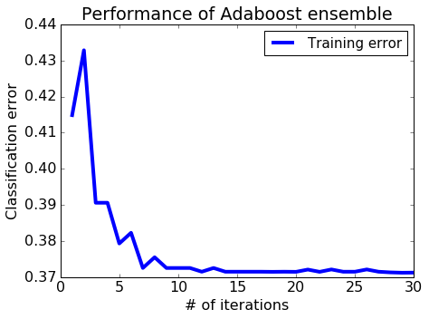

```python
plt.rcParams['figure.figsize'] = 7, 5
plt.plot(range(1,31), error_all, '-', linewidth=4.0, label='Training error')
plt.title('Performance of Adaboost ensemble')
plt.xlabel('# of iterations')
plt.ylabel('Classification error')
plt.legend(loc='best', prop={'size':15})

plt.rcParams.update({'font.size': 16})
```

```python
test_error_all = []
for n in range(1, 31):
    predictions = predict_adaboost(stump_weights[:n], tree_stumps[:n], test_data)
    error = 1.0 - accuracy_score(test_data[target], predictions)
    test_error_all.append(error)
    print ("Iteration %s, test error = %s" % (n, test_error_all[n-1]))
```

```
Iteration 1, test error = 0.41037500000000005
Iteration 2, test error = 0.43174999999999997
Iteration 3, test error = 0.390875
Iteration 4, test error = 0.390875
Iteration 5, test error = 0.37825
Iteration 6, test error = 0.382625
Iteration 7, test error = 0.37175
Iteration 8, test error = 0.37612500000000004
Iteration 9, test error = 0.37175
Iteration 10, test error = 0.37175
Iteration 11, test error = 0.37175
Iteration 12, test error = 0.369375
Iteration 13, test error = 0.369375
Iteration 14, test error = 0.369375
Iteration 15, test error = 0.369375
Iteration 16, test error = 0.369375
Iteration 17, test error = 0.369375
Iteration 18, test error = 0.371
Iteration 19, test error = 0.369375
Iteration 20, test error = 0.371
Iteration 21, test error = 0.36924999999999997
Iteration 22, test error = 0.371
Iteration 23, test error = 0.367625
Iteration 24, test error = 0.369375
Iteration 25, test error = 0.369375
Iteration 26, test error = 0.367625
Iteration 27, test error = 0.369375
Iteration 28, test error = 0.36950000000000005
Iteration 29, test error = 0.369
Iteration 30, test error = 0.369
```

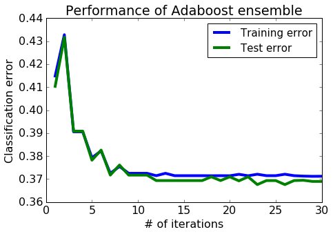

```python
plt.rcParams['figure.figsize'] = 7, 5
plt.plot(range(1,31), error_all, '-', linewidth=4.0, label='Training error')
plt.plot(range(1,31), test_error_all, '-', linewidth=4.0, label='Test error')

plt.title('Performance of Adaboost ensemble')
plt.xlabel('# of iterations')
plt.ylabel('Classification error')
plt.rcParams.update({'font.size': 16})
plt.legend(loc='best', prop={'size':15})
plt.tight_layout()
```

### Question ii: From this plot (with 30 trees), is there massive overfitting as the # of iterations increases?

As the number of iterations increases, the training error is slightly higher than testing error, so there is no overfitting. And we should note that after about 15 iterations, there is not much improvement in classification error.